# Risk HW4

Name: Huanyu Liu  
Group members: Sejal Bharati, Huanyu Liu, Tongsu Peng

```python
import pandas as pd
import numpy as np
import matplotlib.pyplot as plt
import scipy.optimize as opt
from scipy.stats import norm
import sklearn.linear_model as lm
import seaborn as sns
```

### 1.1

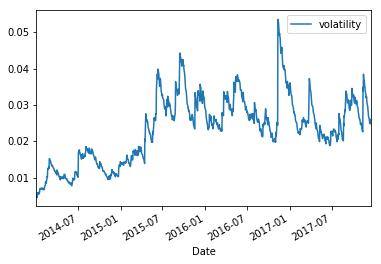

```
          Date  volatility  EWMA VaR
0   2014-01-02    0.004572 -0.010635
1   2014-01-03    0.004673 -0.010871
2   2014-01-06    0.004544 -0.010571
3   2014-01-07    0.005810 -0.013515
4   2014-01-08    0.005636 -0.013111
5   2014-01-09    0.005465 -0.012714
6   2014-01-10    0.005770 -0.013422
7   2014-01-13    0.005656 -0.013157
8   2014-01-14    0.005495 -0.012782
9   2014-01-15    0.006030 -0.014028
10  2014-01-16    0.005928 -0.013789
11  2014-01-17    0.006954 -0.016178
12  2014-01-21    0.006995 -0.016272
13  2014-01-22    0.006824 -0.015875
```

[output cut: 49 more lines]

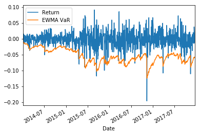

```python
data = pd.read_csv('/Users/huanyu/Desktop/RiskManagement/hw4/hw3_returns2.csv')
lamb = 0.94
data['Date'] = pd.to_datetime(data['Date'])
# data.loc[data['Date'] == '2014-12-31','volatility'] = data.loc[data['Date'] < '2014-12-31','Return'].var()
volatility = list()
volatility.append(data.loc[0,'Return']**2)
for i in data.index[1:]:
    # print(i)
    volatility.append(volatility[i - 1] * lamb + (1 - lamb) * np.power(data.loc[i,'Return'],2))
data['volatility'] = volatility
data['volatility'] = np.sqrt(data['volatility'])
data[['Date','volatility']].plot(x='Date')
plt.show()
data['EWMA VaR'] = data['volatility'] * norm.ppf(0.01)
print(data[['Date','volatility','EWMA VaR']])
exception1 = (data['Return'] < data['EWMA VaR']).value_counts()[True]
data[['Date','Return','EWMA VaR']].plot(x='Date')
plt.show()
```

### 1.2

```
Optimization terminated successfully.
         Current function value: -6479.645680
         Iterations: 212
         Function evaluations: 390
          Date  GARCH_vol  GARCH_VaR
0   2014-01-02   0.013314  -0.030974
1   2014-01-03   0.013270  -0.030870
2   2014-01-06   0.013230  -0.030776
3   2014-01-07   0.013180  -0.030660
4   2014-01-08   0.013199  -0.030704
5   2014-01-09   0.013148  -0.030588
6   2014-01-10   0.013098  -0.030471
7   2014-01-13   0.013074  -0.030414
8   2014-01-14   0.013027  -0.030306
9   2014-01-15   0.012978  -0.030192
```

[output cut: 53 more lines]

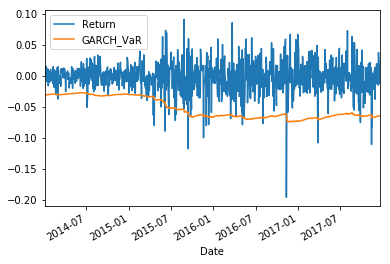

```python
def garch11(omega, alpha, beta, returns):
    length = len(returns)
    sigma_2 = np.zeros(length)
    sigma_2[0] = omega/(1 - alpha - beta)
    for i in range(1,length):
        sigma_2[i] = omega + alpha * returns[i - 1]**2 + beta * sigma_2[i - 1]
    return sigma_2
def garch_log_like(parameters, returns):
    if parameters[1] + parameters[2] >= 1:
        return 0
    elif parameters[0] < 0 or parameters[1] < 0 or parameters[2] < 0:
        return 0
    omega, alhpa, beta = parameters
    sigma_2 = garch11(omega,alhpa,beta,returns)
    log = -np.sum(-np.log(sigma_2) - returns**2/sigma_2)
    return log
parameters0 = [0.1,0.1,0.1]
parameters = opt.fmin(garch_log_like,parameters0,args=(data['Return'],),maxiter=10000)
data['GARCH_vol'] = np.sqrt(garch11(parameters[0],parameters[1],parameters[2],data['Return']))
data['GARCH_VaR'] = data['GARCH_vol'] * norm.ppf(0.01)
exception2 = (data['Return'] < data['GARCH_VaR']).value_counts()[True]
print(data[['Date','GARCH_vol','GARCH_VaR']])
data[['Date','Return','GARCH_VaR']].plot(x='Date')
plt.show()
```

### 1.3

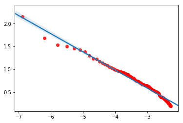

```python
data['monthly_std'] = data['Return'].rolling(22).std().shift(1)
data['normalized_gain'] = (data['Return'] - data['Return'].rolling(22).mean().shift(1)) / data['monthly_std']
normalized_gain = data.loc[22:,'normalized_gain']
normalized_gain = sorted(normalized_gain)
sns.regplot([np.log(x / len(normalized_gain)) for x in range(1,101)],np.log(np.abs(normalized_gain[:100])),scatter_kws={"color": "red"})
plt.show()
```

It's linear in the tail, so the left tail of these normalized returns follows a power law.

```python
def pareto_pdf(xi, beta, y):
    return 1 / beta * np.power(1 + np.multiply(y,xi / beta),-1/xi - 1)

u = abs(data.loc[22:,'normalized_gain'].quantile(0.05))
def pareto_log_like(parameters,y,u):
    return -np.sum(np.log(pareto_pdf(parameters[0],parameters[1],y-u)))

parameters_pareto0 = [0.2,0.8]
parameters_pareto = opt.fmin(pareto_log_like,parameters_pareto0,args=(np.abs(normalized_gain[:49]),u),maxiter=10000)
VaR = u + parameters_pareto[1] / parameters_pareto[0] * (np.power(20 * 0.01,-parameters_pareto[0]) - 1)
VaR *= data.loc[999,'monthly_std']
print(VaR)
```

```
Optimization terminated successfully.
         Current function value: 44.164183
         Iterations: 26
         Function evaluations: 50
0.08031002682921835
```

### 1.4

There are more exceptions for EWMA and GARCH model. However, the trend of the EWMA VaR is similar to the volatility of returns. Thus, you could add capital to invest the stock though the exceptions are not really small. In the opposite, if the VaRs are high and the number of exceptions is small, you will not invest in the stock because of the high VaRs.

### 2.1

The broad trading strategy of LTCM was to take advantage of small differences in prices among closely related securities. They aim for "relative-value", or "convergence-arbitrage", trades. The key is that the securities would ultimately converge to the same value. This was used in a variety of markets, such as long swap-government

spreads, long mortgage-backed securities versus short government, long high-yielding versus short low- yielding European bonds, Japanese convertible bond arbitrage, equity pairs, and so on. LTCM also had other

non-arbitrage strategies, such as short positions in equity options, bets on takeover stocks, emerging market debt, etc. Their trades are usually profitable, unless there is default or market disruption.

### 2.2

They needed a lot of leverage because their trading strategy only generate tiny profits. By using leverage, they can produce much more attractive returns. To control risk, they set their leverage to a target volatility of an unlevered position in US equities. They ended up being four times the asset size of the next largest hedge fund.

### 2.3

1. LTCM was a highly leveraged hedge fund. The 1997, the Debt to Equity Ratio of the fund was 28:1 which was very high.
2. In June 1998 the Firm lost 16% of its capital due to downturn in MBS market, which further increased the leverage ratio to 31:1.
3. On August 17, 1998, Russia de facto defaulted on its Treasury Bonds, which led to global reassessment of Sovereign risks. Since, LTCM’s major book was mostly Interest rates swaps and equity volatility, LTCM suffered huge losses in August due to increase in credit spreads, liquidity spreads and risk premia.
4. By end of August the fund had lost 52% of its Dec 1997 value and the leverage ratio increased from 31 to 55:1.
5. In September, Lenders feared that they would have to liquidate their Repo collaterals, because LTCM would not be able to fulfil its Margin calls, because their capital was substantially reduced, and the firm’s value had reduced too mere $400 millions.
6. This led to the demise of LTCM, at which point the Federal Reserve had to Bailout LTCM to avoid large rippling losses in the entire financial market.

### 2.4

1. LTCM targeted the firm’s volatility to an unlevered position in US Equities. As per volatility calculation, the daily dollar volatility of LTCM was close to $45 millions, as stated by them in May 1998.
2. However, LTCM made some very aggressive assumptions about their volatility calculations:  
   They assumed that Volatility is constant when in fact in turbulent times it can easily double  
   Also, they only focused on Volatility (second) moment which is under the assumption that distribution of PnL is symmetric on both sides. However, credit risks often have higher downside than upside.  
   Also, its distribution in tails cannot be assumed as normal, as we can see from past realized returns that most financial series have fatter tails than normal.
3. When the risk models of the firm had started to blow up, they made another mistake of selling off their most liquid investments, because of less profitability, thereby exposing themselves to liquidity risk.
4. LTCM gave more weightage to recent times, (which were periods of low volatility) and ignored major previous crashes such as 1987 crash or sovereign defaults.

### 2.5

Firstly, historical VaR cannot be used as the sole measure of risk, especially for firms like LTCM which have specialized trading strategies. When measuring the volatility, it is not sufficient to extrapolate from market data when your assets are highly correlated.  
Furthermore, liquidity concerns must be taken into account if access to emergency capital is not guaranteed. For this purpose, the author suggests the use of stress testing to predict the firm’s actual needed equity capital, not by looking at past data, instead of considering possible scenarios for the portfolio in question. We need to take into account that returns are not symmetric and there can be significant tail risk in times when volatility spikes.  
Secondly, to reduce correlation between assets it is safer to diversify the portfolio so catastrophic events do no end up bankrupting the firm.